# Friends data

This uses data from the `friends` package.

Details including the data dictionary can be found here:

https://github.com/rfordatascience/tidytuesday/issues/254

```r
# install.packages("friends")
library(tidytext)
library(tidyverse)
library(here)
library(textdata)
library(ggwordcloud)
library(lubridate)
```

## Load, join and clean data

This creates the object `friends_data`

This contains data from the original tables `friends::friends` and `friends::friends_info`

It also adds some derived fields - for example `season` and `episode` have been combined as `season_episode` (e.g. season 1, episode 1 becomes 1.01)

```r
# Add episode number for all seasons (i.e. one which does not reset to 1 at the start of a new season)
friends_info_edited <- friends::friends_info %>%
  mutate(episode_all_seasons = row_number())

# Import and join data
friends_data <- friends::friends %>%
  left_join(friends::friends_emotions, by = c("season" = "season",
                                              "episode" = "episode",
                                              "scene" = "scene",
                                              "utterance" = "utterance")
  ) %>%
#  left_join(friends::friends_entities, by = c("season" = "season",
#                                              "episode" = "episode",
#                                              "scene" = "scene",
#                                              "utterance" = "utterance")
#  ) %>%
    left_join(friends_info_edited, by = c("season" = "season",
                                            "episode" = "episode")
  ) %>%
  # Get text version of episode with leading zero for single-digit episodes
  mutate(episode_text = ifelse(nchar(episode) > 1,
                               episode,
                               str_c("0", episode, sep = "")
                        )
  ) %>%
  # Add episode text version to season to get numeric value in format "season.episode"
  mutate(season_episode =  as.numeric(str_c(season, episode_text, sep = "."))
  ) %>%
  # add episode number and title
  mutate(episode_number_name = str_c(episode_text, title, sep = " - ")) %>%

  # Get text version of scene with leading zero for single-digit scenes
  mutate(scene_text = ifelse(nchar(scene) > 1,
                               scene,
                               str_c("0", scene, sep = "")
                        )
  ) %>%

  # Get text version of episodescene
  mutate(episode_scene = str_c(episode_text, scene_text, sep = "")) %>%

  # Add episode & scene text versions to season to get numeric value in format "season.episodescene"
  mutate(season_episode_scene =  as.numeric(str_c(season, episode_scene, sep = "."))
  ) %>%

  # Get year of original transmission
  mutate(year_aired = year(air_date)) %>%

  select(-c(episode_text, scene_text, episode_scene))



# output this to a csv
write_csv(friends_data, here("clean_data/friends_data"))
```

## Unnest the text data

This creates the object `friends_words`

Note that stop words have been removed.

Scene directions have also been removed.

```r
# unnest text of utterance into words, remove stop words, add sentiment
friends_words <- friends_data %>%
  filter(speaker != "Scene Directions") %>%
  unnest_tokens(word, text) %>%
  anti_join(stop_words) %>%
  select(-emotion) %>%
  left_join(get_sentiments("bing")) %>%
  left_join(get_sentiments("afinn")) %>%
  rename("sentiment_value" = "value") %>%
  mutate(utterance_id = as.numeric(str_c(season, episode, scene, utterance, sep = "")))
```

## Create a “main characters” vector

For use in subsequent queries

```r
# Create main characters vector
main_characters <- c("Ross Geller", "Monica Geller", "Joey Tribbiani", "Chandler Bing", "Rachel Green", "Phoebe Buffay")
```

## Most common words

These are the fifty most commonly used words over the ten seasons of *Friends* (not including stop words)

The short words like “uh”, “yeah” and “gotta” should probably be excluded, but they do give quite a good indication of dialogue.

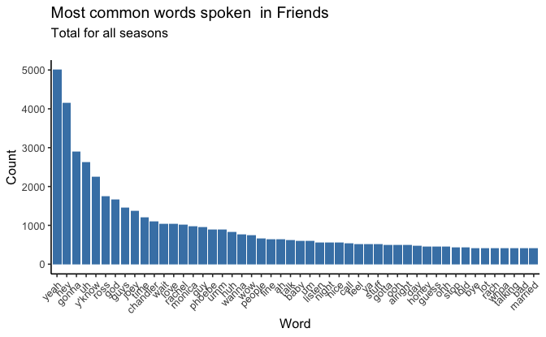

```r
friends_words %>%
  group_by(word) %>%
  summarise(count = n()) %>%
  arrange(desc(count)) %>%
  head(50) %>%
  ggplot()+
  aes(x = reorder(word, -count), y = count)+
  theme(axis.text.x = element_text(angle=45,hjust=1)) +
  theme(panel.grid.major = element_blank(), panel.grid.minor = element_blank(),
panel.background = element_blank(), axis.line = element_line(colour = "black")) +
  geom_col(fill = "steel blue") +
  labs(title = "Most common words spoken  in Friends",
       subtitle = "Total for all seasons  \n",
       x = "Word",
       y = "Count")
```

## Most common words - TF-IDF

I’ll need to look at this again - don’t think my code is working correctly

```r
friends_tf_idf <- friends_words %>%
  count(word, utterance_id) %>%
  bind_tf_idf(term = word, document = utterance_id, n = n) %>%
  arrange(desc(tf_idf))
head(friends_tf_idf)
```

| word | utterance_id | n | tf | idf | tf_idf |
| --- | --- | --- | --- | --- | --- |
| 1250 | 78460 | 1 | 1 | 10.78746 | 10.78746 |
| 12th | 106910 | 1 | 1 | 10.78746 | 10.78746 |
| 131 | 918325 | 1 | 1 | 10.78746 | 10.78746 |
| 1400 | 97315 | 1 | 1 | 10.78746 | 10.78746 |
| 1985 | 816411 | 1 | 1 | 10.78746 | 10.78746 |
| 1986 | 71214 | 1 | 1 | 10.78746 | 10.78746 |

## Most common sentiment words

These are the fifty most common sentiment words which were mapped to an `afinn` sentiment value.

The colour scale shows most positive words in bright green, most negative in bright red.

```r
friends_sentiment_words <- friends_words %>%
  filter(!is.na(sentiment_value)) %>%
  group_by(word, sentiment_value) %>%
  summarise(count = n()) %>%
  arrange(desc(count)) %>%
  head(50)


  friends_sentiment_words %>%
  ggplot()+
    aes(label= word, size = count, colour = sentiment_value) +
      geom_text_wordcloud_area() +
  scale_size_area(max_size = 24) +
  theme_minimal() +
  scale_color_gradient(low = "#d7191c", high = "#1a9641")
```

[output not shown]

## Searches for strings

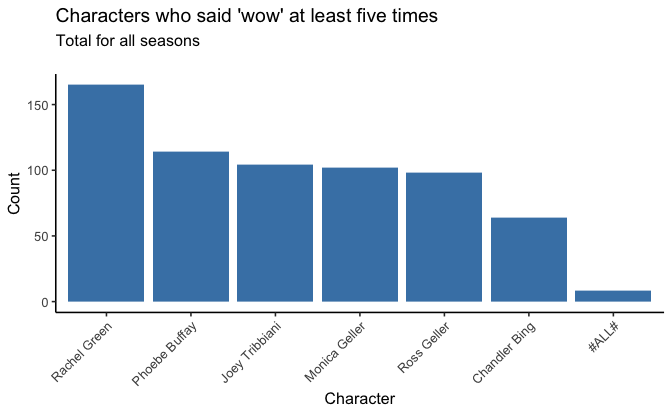

```r
friends_words %>%
  filter(word == "wow") %>%
  group_by(speaker) %>%
  summarise(count = n()) %>%
  filter(count >5) %>%
  arrange(desc(count)) %>%
  ggplot() +
  aes(x = reorder(speaker, -count), y = count) +
    theme(axis.text.x = element_text(angle=45,hjust=1)) +
  theme(panel.grid.major = element_blank(), panel.grid.minor = element_blank(),
panel.background = element_blank(), axis.line = element_line(colour = "black")) +
    geom_col(fill = "steel blue") +
  labs(title = "Characters who said 'wow' at least five times",
       subtitle = "Total for all seasons  \n",
       x = "Character",
       y = "Count")
```

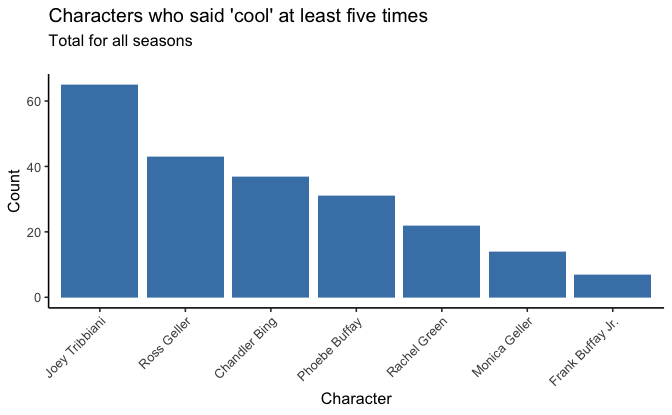

```r
friends_words %>%
  filter(word == "cool") %>%
  group_by(speaker) %>%
  summarise(count = n()) %>%
  filter(count >5) %>%
  arrange(desc(count)) %>%
  ggplot() +
  aes(x = reorder(speaker, -count), y = count) +
    theme(axis.text.x = element_text(angle=45,hjust=1)) +
  theme(panel.grid.major = element_blank(), panel.grid.minor = element_blank(),
panel.background = element_blank(), axis.line = element_line(colour = "black")) +
    geom_col(fill = "steel blue") +
  labs(title = "Characters who said 'cool' at least five times",
       subtitle = "Total for all seasons  \n",
       x = "Character",
       y = "Count")
```

[figure not shown]

```r
friends_data %>%
  filter(str_detect(text, "[Oo][Nn] [Aa] [Bb][Rr][Ee][Aa][Kk]")) %>%
  group_by(speaker) %>%
  summarise(count = n()) %>%
  ggplot() +
  aes(x = reorder(speaker, -count), y = count) +
    theme(axis.text.x = element_text(angle=45,hjust=1)) +
  theme(panel.grid.major = element_blank(), panel.grid.minor = element_blank(),
panel.background = element_blank(), axis.line = element_line(colour = "black")) +
  scale_y_continuous(breaks = 1:10) +
    geom_col(fill = "steel blue") +
  labs(title = "Characters who said 'on a break'",
       subtitle = "Total for all seasons  \n",
       x = "Character",
       y = "Count")
```

```r
NA
NA
```

```r
friends_data %>%
  filter(str_detect(text, "[Oo][Nn] [Aa] [Bb][Rr][Ee][Aa][Kk]")) %>%
  select(season, speaker, text)
```

| season | speaker | text |
| --- | --- | --- |
| 3 | Rachel Green | We were on a break! |
| 3 | Joey Tribbiani | Well, I guess he says that because they were on a break when it happened, that she should of forgiven him by now. |
| 3 | Ross Geller | We were on a break!!! Okay!! We were, we were..., yeah. Where are you? I'll find you. |
| 3 | Ross Geller | We were on a break! |
| 4 | Ross Geller | She wants me to take responsibility for everything that went wrong in our relationship. I mean she goes on for five pages about, about how I was unfaithful to her! WE WERE ON A BREAK!!!!! |
| 4 | Ross Geller | WE WERE ON A BREAK!!!!!!! |
| 4 | Ross Geller | Well, if-if she thought they were on a break... |
| 4 | Ross Geller | WE WERE ON A BREAK!!!!!!! |
| 4 | Passenger | Fortunately, I won't. And by the way, it seems to be perfectly clear that you were on a break. |
| 5 | Ross Geller | This is fun. Hey Rach, remember that whole "We were on a break thing?" Well, I'm sorry, will you marry me? |

[output cut: 8 more lines]

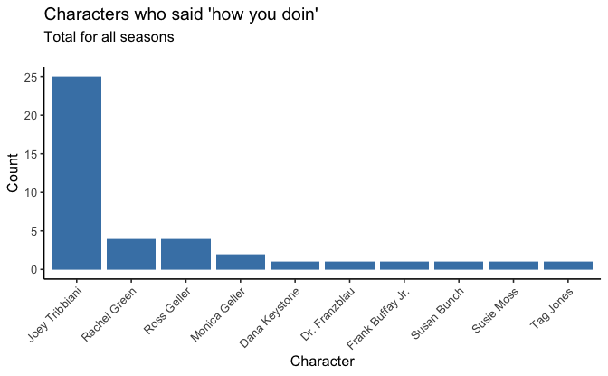

```r
friends_data %>%
  filter(str_detect(text, "[Hh][Oo][Ww] [Yy][Oo][Uu] [Dd][Oo][Ii][Nn]")) %>%
  group_by(speaker) %>%
  summarise(count = n()) %>%
  ggplot() +
  aes(x = reorder(speaker, -count), y = count) +
    theme(axis.text.x = element_text(angle=45,hjust=1)) +
  theme(panel.grid.major = element_blank(), panel.grid.minor = element_blank(),
panel.background = element_blank(), axis.line = element_line(colour = "black")) +
    geom_col(fill = "steel blue") +
  labs(title = "Characters who said 'how you doin'",
       subtitle = "Total for all seasons  \n",
       x = "Character",
       y = "Count")
```

## Mean sentiment value by episode and character

For the main characters, this looks at words which were assigned a positivity value using the `afinn` lexicon

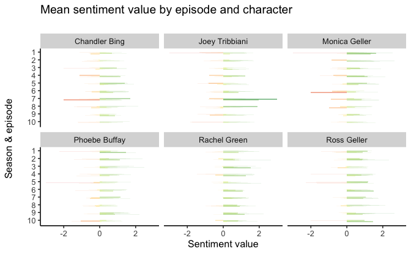

```r
friends_words %>%
  filter(speaker %in% main_characters) %>%
  filter(!is.na(sentiment_value)) %>%
  group_by(speaker, season_episode) %>%
  summarise(sentiment_value = mean(sentiment_value)) %>%
  ggplot()+
  aes(x = season_episode, y = sentiment_value, fill = sentiment_value) +
  geom_col()  +
  coord_flip() +
  theme(legend.position="") +
  theme(panel.grid.major = element_blank(), panel.grid.minor = element_blank(),
panel.background = element_blank(), axis.line = element_line(colour = "black")) +
  scale_fill_gradient2(midpoint = 0, low = "#d7191c", high = "#1a9641", mid = "#ffffbf") +
  scale_x_reverse(limits = c(10.25, 1), breaks = 1:10) +
  facet_wrap(~speaker) +
  labs(
    title = "Mean sentiment value by episode and character \n",
    x = "Season & episode \n",
    y = "Sentiment value"
  )
```

```r
NA
NA
```

## Episodes with lowest mean sentiment value - Ross

```r
friends_words %>%
  filter(speaker == "Ross Geller") %>%
  filter(!is.na(sentiment_value)) %>%
  group_by(season_episode, title) %>%
  summarise(sentiment_value = mean(sentiment_value)) %>%
  arrange(sentiment_value) %>%
  head(5)
```

| season_episode | title | sentiment_value |
| --- | --- | --- |
| 5.13 | The One with Joey's Bag | -2.285714 |
| 4.03 | The One with the Cuffs | -2.000000 |
| 10.03 | The One with Ross's Tan | -2.000000 |
| 5.05 | The One with the Kips | -1.714286 |
| 5.22 | The One with Joey's Big Break | -1.666667 |

```r
NA
```

## Episodes with lowest mean sentiment value - Phoebe

```r
friends_words %>%
  filter(speaker == "Phoebe Buffay") %>%
  filter(!is.na(sentiment_value)) %>%
  group_by(season_episode, title) %>%
  summarise(sentiment_value = mean(sentiment_value)) %>%
  arrange(sentiment_value) %>%
  head(5)
```

| season_episode | title | sentiment_value |
| --- | --- | --- |
| 5.12 | The One with Chandler's Work Laugh | -3.000000 |
| 1.07 | The One with the Blackout | -2.250000 |
| 10.13 | The One Where Joey Speaks French | -1.571429 |
| 2.13 | The One After the Superbowl | -1.416667 |
| 6.16 | The One That Could Have Been | -1.360000 |

```r
NA
```

## Episodes with lowest mean sentiment value - Joey

```r
friends_words %>%
  filter(speaker == "Joey Tribbiani") %>%
  filter(!is.na(sentiment_value)) %>%
  group_by(season_episode, title) %>%
  summarise(sentiment_value = mean(sentiment_value)) %>%
  arrange(sentiment_value) %>%
  head(5)
```

| season_episode | title | sentiment_value |
| --- | --- | --- |
| 1.08 | The One Where Nana Dies Twice | -3.000000 |
| 10.06 | The One with Ross's Grant | -1.833333 |
| 10.10 | The One Where Chandler Gets Caught | -1.727273 |
| 5.05 | The One with the Kips | -1.444444 |
| 9.05 | The One with Phoebe's Birthday Dinner | -1.428571 |

```r
NA
```

## Number of words spoken by main characters per episode

This is the total of all words (including stop words) spoken by the main characters.

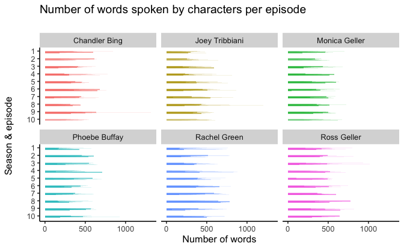

```r
# unnest text of utterance into words, remove stop words, add sentiment
friends_data %>%
  filter(speaker %in% main_characters) %>%
  unnest_tokens(word, text) %>%
  group_by(speaker, season_episode) %>%
  summarise(number_of_words = n()) %>%
ggplot() +
  aes(x = season_episode, y = number_of_words, group = speaker, fill = speaker) +
  geom_col(position = "dodge") +
  coord_flip()+
  scale_x_reverse(limits = c(10.25, 1), breaks = 1:10) +
    theme(panel.grid.major = element_blank(), panel.grid.minor = element_blank(),
panel.background = element_blank(), axis.line = element_line(colour = "black")) +
  facet_wrap(~speaker) +
  theme(legend.position = "") +
    labs(
    title = "Number of words spoken by characters per episode \n",
    x = "Season & episode \n",
    y = "Number of words"
  )
```

## Number of “negative” and “positive” words spoken by main characters

Using the `bing` classifications.

Everyone said more negative than positive.

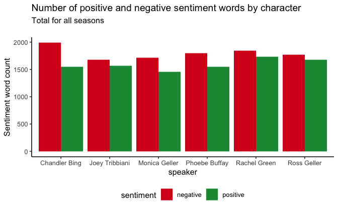

```r
friends_words %>%
  filter(speaker %in% main_characters) %>%
  filter(!is.na(sentiment)) %>%
  group_by(speaker, sentiment) %>%
  summarise(sentiment_count = n()) %>%
  ggplot()+
  aes(x = speaker, y = sentiment_count, fill = sentiment) +
  geom_col(position = "dodge")  +
  theme(legend.position="bottom") +
  theme(panel.grid.major = element_blank(), panel.grid.minor = element_blank(),
panel.background = element_blank(), axis.line = element_line(colour = "black")) +
    scale_fill_manual(
    values = c(
      "positive" = "#1a9641",
      "negative" = "#d7191c"
    )
  )+
  labs(
    title = "Number of positive and negative sentiment words by character ",
    subtitle = "Total for all seasons  \n",
    y = "Sentiment word count"
  )
```

## What do the main characters’ sentiments look like on a scene-by-scene basis?

[figure not shown]

```r
friends_words %>%
  filter(!is.na(sentiment_value)) %>%
  filter(speaker %in% main_characters) %>%
  group_by(speaker, season_episode_scene) %>%
  summarise(sentiment_value = mean(sentiment_value)) %>%
  arrange(speaker, season_episode_scene) %>%
  mutate(scene_n = row_number()) %>%
  mutate(timeline_position = scene_n/max(scene_n)) %>%

   ggplot +
    aes(x = timeline_position, y = sentiment_value, colour = speaker) +
      geom_line() +
      guides(colour = FALSE) +
      facet_wrap(~speaker, nrow = 6) +
  theme(panel.grid.major = element_blank(), panel.grid.minor = element_blank(),
panel.background = element_blank(), axis.line = element_line(colour = "black"))
```

## Mean character sentiment per season

[figure not shown]

```r
friends_words %>%
  filter(!is.na(sentiment_value)) %>%
  filter(speaker %in% main_characters) %>%
  group_by(speaker, season) %>%
  summarise(sentiment_value = mean(sentiment_value)) %>%
  arrange(speaker, season) %>%


   ggplot +
    aes(x = season, y = sentiment_value, colour = speaker) +
      geom_line() +
      guides(colour = FALSE) +
      facet_wrap(~speaker, nrow = 6) +
  theme(panel.grid.major = element_blank(), panel.grid.minor = element_blank(),
panel.background = element_blank(), axis.line = element_line(colour = "black")) +
  scale_x_continuous(breaks = 1:10)
```

## It was acceptable in the 90s…

Lots of people have noted that Friends can be pretty cringy in places when you watch it now - I’m trying a few bits of analysis to see if I can highlight anything:

### Sexist language

This checks for 20 terms mentioned in this survey:

https://www.stylist.co.uk/life/sexist-feminist-special-k-strength-is-nicola-roberts-emily-blunt-hollywood-language-gender/66378

```r
# Create words vector
sexist_words <- c("hormonal",  "bitchy", "hysterical","diva", "mumsy", "princess",  "emotional", "manipulative", "bossy", "controlling", "difficult", "sexy", "aggressive", "sassy", "feisty")

# Create bigrams vector
sexist_bigrams <- c("drama queen", "high maintenance","ball breaker","highly strung","attention seeking")
```

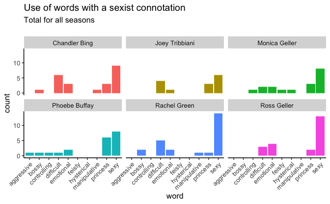

```r
# Sexist words
friends_words %>%
  filter(word %in% sexist_words) %>%
  filter(speaker %in% main_characters) %>%
  group_by(word, speaker) %>%
  summarise(count = n()) %>%
  ggplot()+
  aes(x = word, y = count, fill = speaker) +
  geom_col() +
  facet_wrap(~speaker) +
    theme(panel.grid.major = element_blank(), panel.grid.minor = element_blank(),
panel.background = element_blank(), axis.line = element_line(colour = "black")) +
  theme(axis.text.x = element_text(angle = 45, hjust=1)) +
  theme(legend.position = "") +
  labs(title = "Use of words with a sexist connotation",
       subtitle = "Total for all seasons  \n")
```

### Which writers used these words most often?

[figure not shown]

```r
# Sexist words
friends_words %>%
  filter(word %in% sexist_words) %>%
  filter(speaker != "Scene Directions") %>%
  group_by(written_by) %>%
  summarise(count = n()) %>%
  filter(count > 2) %>%
  arrange(desc(count)) %>%
  ggplot()+
  aes(x = reorder(written_by, -count), y = count) +
  geom_col() +
    theme(panel.grid.major = element_blank(), panel.grid.minor = element_blank(),
panel.background = element_blank(), axis.line = element_line(colour = "black")) +
  theme(axis.text.x = element_text(angle = 45, hjust=1)) +
  theme(legend.position = "") +
  labs(title = "Number of words with a sexist connotation by writer",
       subtitle = "Total for all seasons  \n")
```

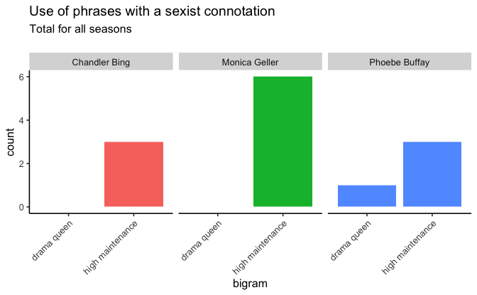

```r
# Sexist bigrams

friends_data %>%
  unnest_tokens(bigram, text, token = "ngrams", n = 2) %>%
  filter(bigram %in% sexist_bigrams) %>%
  filter(speaker %in% main_characters) %>%
  group_by(bigram, speaker) %>%
  summarise(count = n()) %>%
  ggplot()+
  aes(x = bigram, y = count, fill = speaker) +
  geom_col() +
  facet_wrap(~speaker) +
    theme(panel.grid.major = element_blank(), panel.grid.minor = element_blank(),
panel.background = element_blank(), axis.line = element_line(colour = "black")) +
  theme(axis.text.x = element_text(angle = 45, hjust=1)) +
  theme(legend.position = "") +
  labs(title = "Use of phrases with a sexist connotation",
       subtitle = "Total for all seasons  \n")
```

### Number of times a character used the word “bitch”, by year of original transmission

[figure not shown]

```r
friends_data %>%
  filter(speaker %in% main_characters) %>%
  filter(str_detect(text, "[Bb][Ii][Tt][Cc][Hh]")) %>%
  group_by(speaker, year_aired) %>%
  summarise(count = n()) %>%
  ggplot()+
  aes(x = year_aired, y = count, fill = speaker) +
  geom_col() +
  facet_wrap(~speaker) +
    theme(panel.grid.major = element_blank(), panel.grid.minor = element_blank(),
panel.background = element_blank(), axis.line = element_line(colour = "black")) +
  theme(axis.text.x = element_text(angle = 45, hjust=1)) +
  theme(legend.position = "") +
  scale_x_continuous(breaks = min(friends_data$year_aired):max(friends_data$year_aired))
```

```r
friends_data %>%
  filter(speaker == "Chandler Bing") %>%
  filter(str_detect(text, "[Bb][Ii][Tt][Cc][Hh]")) %>%
  select(text, speaker, year_aired)
```

| text | speaker | year_aired |
| --- | --- | --- |
| Yeah, well, you wouldn't think it was cool if you're eleven years old and all your friends are passing around page 79 of 'Mistress Bitch.' | Chandler Bing | 1995 |
| Crazy bitch. | Chandler Bing | 1995 |
| Of course I am. I reject anyone who's crazy enough to actually go out with me, and then I bitch about the fact that there aren't any great women out there. | Chandler Bing | 1995 |
| You bitch. | Chandler Bing | 1995 |
| Becasue it reminded you of the way our forefathers used to bitch at each other? | Chandler Bing | 1996 |
| Really, bitchin'! | Chandler Bing | 1997 |
| No, see the thing is I want to get out of here before Joey gets all worked up and starts calling everybody bitch. | Chandler Bing | 2000 |
| Oh no-no-no, Monica would freak. But to hell with that bitch. | Chandler Bing | 2001 |
| That fake British woman is a real bitch, but she sure can dance... Hey! | Chandler Bing | 2003 |
| Yeah! I... I... I liked it! But, ehm... my bosses didn't go for it. Stupid sons of bitches! | Chandler Bing | 2003 |

[output cut: 1 more lines]

### Number of uses of the word “lesbian”

The “Ross and his lesbian ex wife” storyline is one of the more cringeworthy elements of the programme - examples shown below the graph.

[figure not shown]

```r
friends_data %>%
filter(speaker %in% main_characters) %>%
filter(str_detect(text, "[Ll][Ee][Ss][Bb][Ii][Aa][Nn]")) %>%
group_by(speaker, year_aired) %>%
summarise(count = n()) %>%
  ggplot()+
  aes(x = year_aired, y = count, fill = speaker) +
  geom_col() +
  facet_wrap(~speaker) +
    theme(panel.grid.major = element_blank(), panel.grid.minor = element_blank(),
panel.background = element_blank(), axis.line = element_line(colour = "black")) +
  theme(axis.text.x = element_text(angle = 45, hjust=1)) +
  theme(legend.position = "") +
  scale_x_continuous(breaks = min(friends_data$year_aired):max(friends_data$year_aired))
```

```r
friends_data %>%
filter(speaker == "Ross Geller") %>%
filter(str_detect(text, "[Ll][Ee][Ss][Bb][Ii][Aa][Nn]")) %>%
  select(text, speaker)
```

| text | speaker |
| --- | --- |
| Okay! Okay. Look, I, uh- I realise you guys have been wondering what exactly happened between Carol and me, and, so, well, here's the deal. Carol's a lesbian. She's living with a woman named Susan. Sh… | Ross Geller |
| Today's the day Carol and I first.. consummated our physical relationship. Sex. ..You know what, I-I'd better pass on the game. I think I'm just gonna go home and think about my ex-wife and her lesbia… | Ross Geller |
| It is. Eventually, it kind of... burns out. But hopefully, what you're left with is trust, and security, and... well, in the case of my ex-wife, lesbianism. So, you know, for all of those people who m… | Ross Geller |
| Ooh, ooh. Because she's my ex-wife, and will probably want to bring her, ooh, ooh, lesbian life partner. | Ross Geller |
| Ok. Wow, you guys sure have a lot of books about bein' a lesbian. | Ross Geller |
| Y'see, that's where you're wrong. Why would I marry her if I thought on any level thatthat she was a lesbian? | Ross Geller |
| Hey, I married a lesbian to make you look good! | Ross Geller |
| No, it's just...you know the whole "getting on with your life" thing. Well, do I have to? I mean, I'm sitting here with this cute woman, and, and, and she's perfectly nice, and, but that there's, that… | Ross Geller |
| No, Susans gonna be there too. Weve got dads, weve got lesbians, the whole parenting team. | Ross Geller |
| Every day is Lesbian Lover Day. | Ross Geller |

[output cut: 7 more lines]